# Linear Regression

# Regression is the procedure where we model a response variable, Y, using a linear combination of predictor variables, X1, X2, etc.

Classic regression is focused on understanding the relationship between predictors and response variables. Machine Learning (“Predictive modeling”) is focused on using the best predictors and model to generate predictions for new data.

Here we are modeling the performance in fermentation (Yield) using the small-scale assay data.

(Preliminary: Load useful libraries)

```r
library(tidyverse)
```

Load the response data (Y):

```r
Y <- "Tier3_yields.csv" %>% read.csv
Y
```

| strain_id | Y |
| --- | --- |
| s115 | 0.25682703 |
| s115 | 0.26564571 |
| s115 | 0.25031255 |
| s115 | 0.24330318 |
| s73 | 0.16060078 |
| s73 | 0.16553451 |
| s73 | 0.12580524 |
| s73 | 0.16829184 |
| s38 | 0.09961823 |
| s38 | 0.11686754 |

[output cut: 390 more lines]

Find median values and use as representative values for strains:

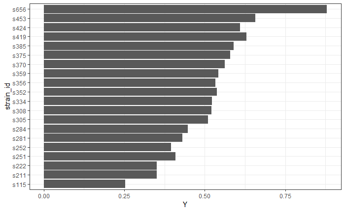

```r
Y.med <- Y %>% group_by(strain_id) %>% summarise_all(funs(Y = median))
p <- ggplot(data = sample_n(Y.med, 20), aes(x = strain_id, y = Y)) + geom_bar(stat = "identity") + coord_flip() + theme_bw() #only looking at 20 strains here
p
```

Now, load the predictors (X) - small-scale assay data.

```r
X <- "C:\\Users\\jabus\\OneDrive\\Documents\\2459\\Delv Bio\\Clients\\Novo Nordisk UCSD\\stats course\\dev\\Tier2 data\\Tier2_plate_data.csv" %>% read.csv
str(X)
```

```
'data.frame':   800 obs. of  7 variables:
 $ strain_id: Factor w/ 100 levels "s109","s115",..: 2 2 2 2 2 2 2 2 98 98 ...
 $ X1       : num  0.1112 0.0689 0.0934 0.082 0.1159 ...
 $ X2       : num  0.345 0.323 0.36 0.374 0.373 ...
 $ X3       : num  0.48 0.553 0.534 0.523 0.528 ...
 $ X4       : num  0.837 0.914 0.814 0.828 0.857 ...
 $ X5       : num  0.556 0.59 0.629 0.609 0.614 ...
 $ X6       : num  0.0705 0.0131 0.1409 0.092 0.1014 ...
```

Find median values

```r
X.med <- X %>% group_by(strain_id) %>% summarise_all(funs(median))
X.med
```

| strain_id | X1 | X2 | X3 | X4 | X5 | X6 |
| --- | --- | --- | --- | --- | --- | --- |
| s109 | 0.35686150 | 0.3905706 | 0.63051701 | 0.8722836 | 0.7039535 | 0.38496162 |
| s115 | 0.10685927 | 0.3584240 | 0.50133621 | 0.8326405 | 0.5997403 | 0.06739782 |
| s116 | 0.36782696 | 0.2894836 | 0.50909363 | 0.6039285 | 0.6451265 | 0.63067168 |
| s169 | 0.38854275 | 0.3479469 | 0.42835041 | 0.6658546 | 0.6565230 | 0.56673763 |
| s196 | 0.40169908 | 0.4008751 | 0.38610677 | 0.6468959 | 0.7660402 | 0.69987727 |
| s202 | 0.26242210 | 0.4784738 | 0.57633868 | 0.3787168 | 0.5121565 | 0.50156432 |
| s208 | 0.45144415 | 0.6685701 | 0.37919401 | 0.5204041 | 0.6339437 | 0.50960219 |
| s209 | 0.42467888 | 0.3738521 | 0.52310810 | 0.7103803 | 0.4689200 | 0.57712041 |
| s211 | 0.44234993 | 0.5235799 | 0.44229829 | 0.7199300 | 0.6085069 | 0.46123360 |
| s213 | 0.27974384 | 0.3955700 | 0.39434249 | 0.6036699 | 0.6130347 | 0.39209093 |

[output cut: 90 more lines]

Now, we join the Y and X dataframes together:

```r
mydata <- left_join(Y.med, X.med, by="strain_id")
mydata
```

| strain_id | Y | X1 | X2 | X3 | X4 | X5 | X6 |
| --- | --- | --- | --- | --- | --- | --- | --- |
| s109 | 0.2505136 | 0.35686150 | 0.3905706 | 0.63051701 | 0.8722836 | 0.7039535 | 0.38496162 |
| s115 | 0.2535698 | 0.10685927 | 0.3584240 | 0.50133621 | 0.8326405 | 0.5997403 | 0.06739782 |
| s116 | 0.2790658 | 0.36782696 | 0.2894836 | 0.50909363 | 0.6039285 | 0.6451265 | 0.63067168 |
| s169 | 0.3038607 | 0.38854275 | 0.3479469 | 0.42835041 | 0.6658546 | 0.6565230 | 0.56673763 |
| s196 | 0.3598729 | 0.40169908 | 0.4008751 | 0.38610677 | 0.6468959 | 0.7660402 | 0.69987727 |
| s202 | 0.3297151 | 0.26242210 | 0.4784738 | 0.57633868 | 0.3787168 | 0.5121565 | 0.50156432 |
| s208 | 0.3570212 | 0.45144415 | 0.6685701 | 0.37919401 | 0.5204041 | 0.6339437 | 0.50960219 |
| s209 | 0.3728047 | 0.42467888 | 0.3738521 | 0.52310810 | 0.7103803 | 0.4689200 | 0.57712041 |
| s211 | 0.3514379 | 0.44234993 | 0.5235799 | 0.44229829 | 0.7199300 | 0.6085069 | 0.46123360 |
| s213 | 0.3567419 | 0.27974384 | 0.3955700 | 0.39434249 | 0.6036699 | 0.6130347 | 0.39209093 |

[output cut: 90 more lines]

# Data splitting: Training and test sets

```r
prop_training <- 0.70 #split proportion (training vs testing)
set.seed(123) #for reproducibility
sample <- sample.int(n = nrow(mydata)
                     , size = floor(prop_training*nrow(mydata)))
train <- mydata[sample,]
test <- mydata[-sample,]
```

Let’s build a basic linear regression model, and view the model summary statistics:

```r
m1 <- lm(Y ~ X1, data = train) #model 1, using training data
summary(m1)
```

```
Call:
lm(formula = Y ~ X1, data = train)

Residuals:
     Min       1Q   Median       3Q      Max
-0.29728 -0.08280  0.00705  0.06916  0.27968

Coefficients:
            Estimate Std. Error t value Pr(>|t|)
(Intercept)  0.14825    0.05426   2.732  0.00801 **
X1           0.76615    0.11016   6.955 1.71e-09 ***
---
Signif. codes:
0 ‘***’ 0.001 ‘**’ 0.01 ‘*’ 0.05 ‘.’ 0.1 ‘ ’ 1

Residual standard error: 0.114 on 68 degrees of freedom
Multiple R-squared:  0.4157,    Adjusted R-squared:  0.4071
F-statistic: 48.37 on 1 and 68 DF,  p-value: 1.71e-09
```

Basic plot of our regression model:

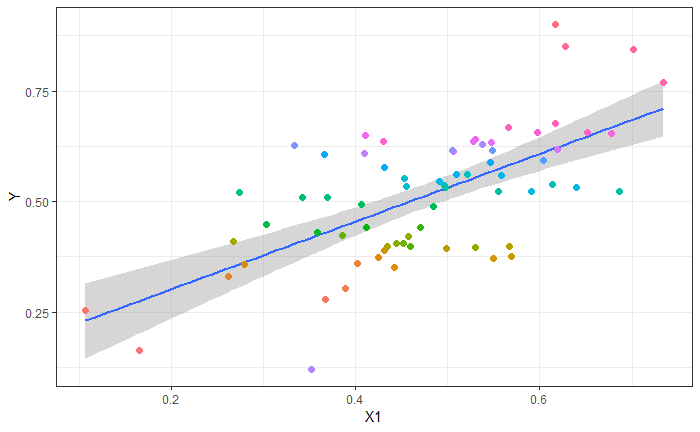

```r
ggplot(data = train, aes(x = X1, y= Y)) +
  geom_smooth(method = "lm") +
  geom_point(aes(col = strain_id), size=2) +
  theme_bw() +
  theme(legend.position="none")
```

# New model m2: Let’s consider two terms.

Plot Y as a function of X1, X2:

```r
mydata.2 <- mydata %>% select(strain_id, Y, X1, X2)
mydata.2
```

| strain_id | Y | X1 | X2 |
| --- | --- | --- | --- |
| s109 | 0.2505136 | 0.35686150 | 0.3905706 |
| s115 | 0.2535698 | 0.10685927 | 0.3584240 |
| s116 | 0.2790658 | 0.36782696 | 0.2894836 |
| s169 | 0.3038607 | 0.38854275 | 0.3479469 |
| s196 | 0.3598729 | 0.40169908 | 0.4008751 |
| s202 | 0.3297151 | 0.26242210 | 0.4784738 |
| s208 | 0.3570212 | 0.45144415 | 0.6685701 |
| s209 | 0.3728047 | 0.42467888 | 0.3738521 |
| s211 | 0.3514379 | 0.44234993 | 0.5235799 |
| s213 | 0.3567419 | 0.27974384 | 0.3955700 |

[output cut: 90 more lines]

Gather data into a tidy dataframe:

```r
mydata.2.long <- mydata.2 %>% gather(key = X, value = value
                    , -strain_id, -Y)
mydata.2.long
```

| strain_id | Y | X | value |
| --- | --- | --- | --- |
| s109 | 0.2505136 | X1 | 0.35686150 |
| s115 | 0.2535698 | X1 | 0.10685927 |
| s116 | 0.2790658 | X1 | 0.36782696 |
| s169 | 0.3038607 | X1 | 0.38854275 |
| s196 | 0.3598729 | X1 | 0.40169908 |
| s202 | 0.3297151 | X1 | 0.26242210 |
| s208 | 0.3570212 | X1 | 0.45144415 |
| s209 | 0.3728047 | X1 | 0.42467888 |
| s211 | 0.3514379 | X1 | 0.44234993 |
| s213 | 0.3567419 | X1 | 0.27974384 |

[output cut: 190 more lines]

Now we can plot both regression terms:

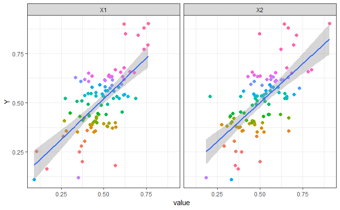

```r
ggplot(data = mydata.2.long, aes(x = value, y = Y)) +
  facet_wrap(~X) +
  geom_point(aes(col=strain_id), size = 2) +
  geom_smooth(method = "lm") +
  theme_bw() +
  theme(legend.position = "none")
```

Model m2 (with two predictors):

```r
m2 <- lm(Y ~ X1 + X2, data = train) #model 2
summary(m2)
```

```
Call:
lm(formula = Y ~ X1 + X2, data = train)

Residuals:
      Min        1Q    Median        3Q       Max
-0.185161 -0.065385  0.001937  0.046490  0.254121

Coefficients:
            Estimate Std. Error t value Pr(>|t|)
(Intercept) -0.03939    0.05563  -0.708    0.481
X1           0.57338    0.09713   5.903 1.31e-07 ***
X2           0.55369    0.09710   5.702 2.90e-07 ***
---
Signif. codes:
0 ‘***’ 0.001 ‘**’ 0.01 ‘*’ 0.05 ‘.’ 0.1 ‘ ’ 1

Residual standard error: 0.09423 on 67 degrees of freedom
Multiple R-squared:  0.6066,    Adjusted R-squared:  0.5948
F-statistic: 51.65 on 2 and 67 DF,  p-value: 2.675e-14
```

# How do we compare between models, m1 and m2?

One good option is an error metric called RMSE (root mean squared error). It’s critical that we use the test data (not the training data) - better accounts for uncertainty in the model.

```r
test$m1 <- predict(m1, test)
test$m2 <- predict(m2, test)
rmse.data <- test %>% select(strain_id, Y, m1, m2) %>%
  gather(key = model, value = predicted
         , -strain_id, -Y)
rmse <- function(p,o) {
  return(sqrt(mean((p - o)^2)))
}
m1.RMSE <- rmse(test$m1, test$Y)
m2.RMSE <- rmse(test$m2, test$Y)
RMSE <- c(m1.RMSE, m2.RMSE)
Model <- c("M1", "M2")
RMSEs <- as.data.frame(cbind(Model, RMSE))
RMSEs$RMSE <- as.numeric(as.character(RMSEs$RMSE))
RMSEs
```

| Model | RMSE |
| --- | --- |
| M1 | 0.1320519 |
| M2 | 0.1102807 |

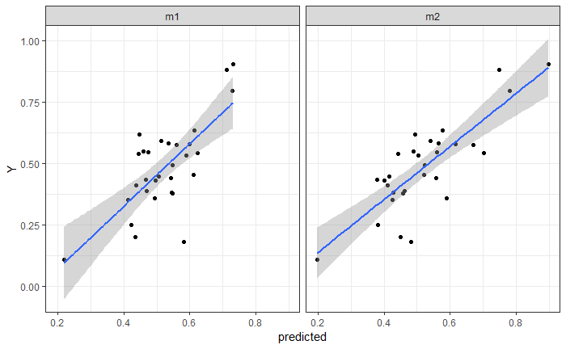

```r
ggplot(rmse.data, aes(predicted, Y, group=model)) +
  facet_wrap(~model) +
  geom_point() +
  geom_smooth(method="lm") +
  theme_bw()
```

```r
NA
```

Model 2 has a lower RMSE (0.11) compared to Model 1 (0.13). One way to interpret RMSE is the standard deviation of the unexplained uncertainty in the model (lower is better). One nice component of RMSE is that it is in the same units as Y.

# Regression assumes no (or little) multicollinearity (correlation among predictor variables):

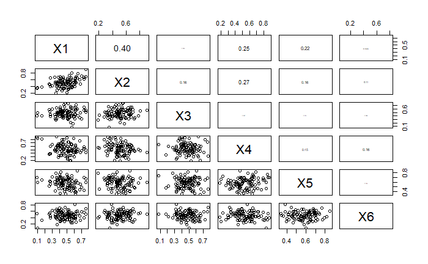

```r
panel.cor <- function(x, y, digits = 2, prefix = "", cex.cor, ...)
{
    usr <- par("usr"); on.exit(par(usr))
    par(usr = c(0, 1, 0, 1))
    r <- abs(cor(x, y))
    txt <- format(c(r, 0.123456789), digits = digits)[1]
    txt <- paste0(prefix, txt)
    if(missing(cex.cor)) cex.cor <- 0.8/strwidth(txt)
    text(0.5, 0.5, txt, cex = cex.cor * r)
}
pairs(X.med[2:ncol(X.med)], upper.panel = panel.cor)
```

The above ‘pairs’ plot is a quick sketch among all pairs of predictor varialbes (below the diagonal) and the associated correlation coefficient (r) is above the diagonal.

Two approaches for reducing collinearity: Remove ‘redundant’ terms (i.e., correlated), or conduct PCA to generate new predictors that are uncorrelated.

Save joined data to a .csv file

```r
mydata %>% write.csv(file="joined_data.csv", row.names=FALSE)
```